# P0 cortex

```r
library(COTAN)
library(data.table)
library(Matrix)
library(ggrepel)
#library(latex2exp)
```

```r
mycolours <- c("A" = "#8491B4B2","B"="#E64B35FF")
my_theme = theme(axis.text.x = element_text(size = 14, angle = 0, hjust = .5, vjust = .5, face = "plain", colour ="#3C5488FF" ),
                 axis.text.y = element_text( size = 14, angle = 0, hjust = 0, vjust = .5, face = "plain", colour ="#3C5488FF"),
                 axis.title.x = element_text( size = 14, angle = 0, hjust = .5, vjust = 0, face = "plain", colour ="#3C5488FF"),
                 axis.title.y = element_text( size = 14, angle = 90, hjust = .5, vjust = .5, face = "plain", colour ="#3C5488FF"))
```

Download the dataset for mouse cortex P0.

```r
data_dir = "Data/Mouse2/"
```

```r
data = as.data.frame(fread(paste(data_dir,"GSE123335_P0_combined_matrix.txt.gz", sep = "/")))
data = as.data.frame(data)
rownames(data) = data$Gene
data = data[,2:ncol(data)]
data[1:10,1:10]
```

|  | p0-WT2_AAAACATGAACC | p0-WT2_AAAAGACACCAC | p0-WT2_AAAAGGCTCGTG | p0-WT2_AAAATACGCAAG | p0-WT2_AAACACCGGATA | p0-WT2_AAACACCGGGCA | p0-WT2_AAACAGGTCCGT | p0-WT2_AAACCATCACTA | p0-WT2_AAACCTACTCTT | p0-WT2_AAACCTCATTTC |
| --- | --- | --- | --- | --- | --- | --- | --- | --- | --- | --- |
| 0610005C13Rik | 0 | 0 | 0 | 0 | 0 | 0 | 0 | 0 | 0 | 0 |
| 0610007N19Rik | 0 | 0 | 0 | 0 | 0 | 0 | 0 | 0 | 0 | 0 |
| 0610007P14Rik | 0 | 0 | 0 | 0 | 3 | 0 | 1 | 0 | 0 | 0 |
| 0610009B22Rik | 0 | 0 | 0 | 0 | 1 | 0 | 1 | 1 | 1 | 0 |
| 0610009D07Rik | 0 | 0 | 0 | 1 | 0 | 1 | 0 | 0 | 3 | 1 |
| 0610009E02Rik | 0 | 0 | 0 | 0 | 0 | 0 | 0 | 2 | 0 | 0 |
| 0610009L18Rik | 0 | 0 | 0 | 0 | 0 | 0 | 0 | 0 | 0 | 0 |
| 0610009O20Rik | 0 | 0 | 0 | 0 | 0 | 0 | 0 | 1 | 0 | 0 |
| 0610010F05Rik | 0 | 3 | 1 | 0 | 0 | 0 | 0 | 0 | 0 | 0 |
| 0610010K14Rik | 0 | 0 | 0 | 0 | 0 | 0 | 0 | 0 | 0 | 0 |

Define a directory where the ouput will be stored.

```r
out_dir = "Data/"
```

## 0.1 Analitical pipeline

Inizialise the COTAN object with the row count table and the metadata for the experiment.

```r
obj = new("scCOTAN",raw = data)
obj = initRaw(obj,GEO="GSE123335" ,sc.method="10X",cond = "mouse cortex P0")
```

```
[1] "Initializing S4 object"
```

Now we can start the cleaning. Analysis requires and starts from a matrix of raw UMI counts after removing possible cell doublets or multiplets and low quality or dying cells (with too high mtRNA percentage, easily done with Seurat or other tools).

If we do not want to consider the mithocondrial genes we can remove them before starting the analysis.

```r
genes_to_rem = rownames(obj@raw[grep('^mt', rownames(obj@raw)),]) #genes to remove : mithocondrial
obj@raw = obj@raw[!rownames(obj@raw) %in% genes_to_rem,]
cells_to_rem = colnames(obj@raw[which(colSums(obj@raw) == 0)])
obj@raw = obj@raw[,!colnames(obj@raw) %in% cells_to_rem]
```

We want also to define a prefix to identify the sample.

```r
t = "P0_cortex"

print(paste("Condition ",t,sep = ""))
```

```
[1] "Condition P0_cortex"
```

```r
#--------------------------------------
n_cells = length(colnames(obj@raw))
print(paste("n cells", n_cells, sep = " "))
```

```
[1] "n cells 7688"
```

```r
n_it = 1

#obj@raw = obj@raw[rownames(cells), colnames(cells)]
```

## 0.2 Data cleaning

First we create the directory to store all information regardin the data cleaning.

```r
if(!file.exists(out_dir)){
  dir.create(file.path(out_dir))
}

if(!file.exists(paste(out_dir,"cleaning", sep = ""))){
  dir.create(file.path(out_dir, "cleaning"))
}
```

```r
ttm = clean(obj)
```

```
[1] "Start estimation mu with linear method"
[1] 14438  7688
```

|  | rowname | p0-WT2_ACGAGCGATAGA | p0-WT2_CAATCAGTTCAT | p0-WT2_CAGTACCACATA | p0-WT2_TCAGCCAGGCAT | p0-WT3_ACCAATCGACAG | p0-WT3_ATCTCTTGCTGG | p0-WT3_GGATTGACAGGA | p0-WT3_GTGAGATTCGAA | p0-WT3_TACCGATCAAAG | p0-WT3_TGAGGAATGAGA | p0-WT4_CCGCAAAGCACT | p0-WT4_TCCTTTAACCTT | p0-WT4_TCGTGGTCGTCA |
| --- | --- | --- | --- | --- | --- | --- | --- | --- | --- | --- | --- | --- | --- | --- |
| 8624 | Npy | 269.054089 | 260.832176 | 420.693732 | 165.023143 | 198.814905 | 158.297051 | 227.695969 | 89.091134 | 194.188936 | 240.738358 | 175.421286 | 162.138055 | 260.0206889 |
| 12065 | Sst | 102.371800 | 78.642867 | 102.935700 | 87.365193 | 46.841208 | 47.659327 | 72.368486 | 189.604208 | 41.316795 | 78.379930 | 57.861471 | 58.467965 | 65.6617901 |
| 13263 | Tuba1a | 18.374426 | 9.175001 | 19.393683 | 53.389840 | 11.450073 | 25.531782 | 12.355595 | 31.981433 | 26.167303 | 13.436560 | 25.716209 | 16.213806 | 14.8833391 |
| 7440 | Malat1 | 36.748851 | 0.000000 | 1.491822 | 0.000000 | 31.227472 | 6.808475 | 1.765085 | 41.118985 | 13.772265 | 23.513979 | 16.531849 | 37.340885 | 59.5333564 |
| 8551 | Nnat | 26.249179 | 18.350002 | 17.901861 | 26.694920 | 14.572820 | 11.914832 | 24.711190 | 15.990716 | 15.149491 | 8.957706 | 33.063698 | 20.144425 | 14.0078486 |
| 7679 | Meg3 | 26.249179 | 3.932143 | 0.000000 | 0.000000 | 12.490989 | 0.000000 | 0.000000 | 38.834597 | 20.658397 | 15.675986 | 20.205593 | 21.127080 | 38.5215835 |
| 847 | Actb | 22.311802 | 13.107145 | 10.442752 | 24.268109 | 15.613736 | 8.510594 | 10.590510 | 9.137552 | 22.035624 | 10.077420 | 11.021233 | 9.335221 | 2.6264716 |
| 2115 | Calm1 | 6.562295 | 7.864287 | 13.426396 | 12.134055 | 6.245494 | 18.723307 | 3.530170 | 18.275104 | 15.149491 | 12.316846 | 3.673744 | 3.930620 | 6.1284337 |
| 9101 | Pcp4 | 0.000000 | 6.553572 | 5.967287 | 19.414487 | 16.654652 | 0.000000 | 17.650850 | 4.568776 | 19.281171 | 2.239427 | 6.429052 | 4.913274 | 12.2568675 |
| 6352 | Hsp90ab1 | 6.562295 | 19.660717 | 5.967287 | 4.853622 | 7.286410 | 13.616951 | 7.060340 | 4.568776 | 12.395038 | 10.077420 | 5.510616 | 1.965310 | 13.1323580 |

[output cut: 5 more lines]

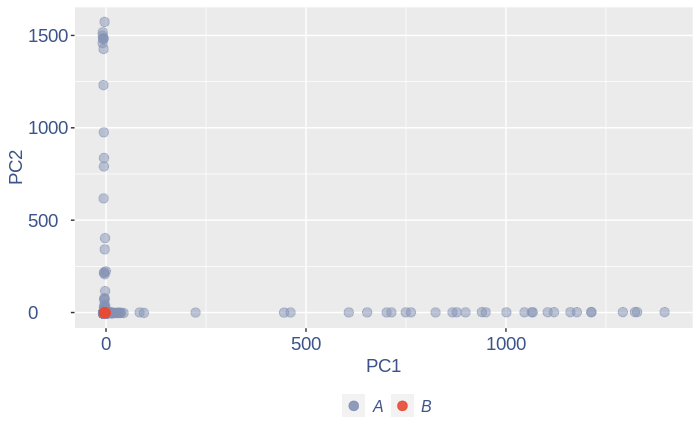

```r
obj = ttm$object

ttm$pca.cell.2
```

Run this when B cells need to be removed.

```r
pdf(paste(out_dir,"cleaning/",t,"_",n_it,"_plots_before_cells_exlusion.pdf", sep = ""))
ttm$pca.cell.2
ggplot(ttm$D, aes(x=n,y=means)) + geom_point() +
  geom_text_repel(data=subset(ttm$D, n > (max(ttm$D$n)- 15) ), aes(n,means,label=rownames(ttm$D[ttm$D$n > (max(ttm$D$n)- 15),])),
                  nudge_y      = 0.05,
                  nudge_x      = 0.05,
                  direction    = "x",
                  angle        = 90,
                  vjust        = 0,
                  segment.size = 0.2)+
  ggtitle("B cell group genes mean expression")+my_theme +
  theme(plot.title = element_text(color = "#3C5488FF", size = 20, face = "italic",vjust = - 5,hjust = 0.02 ))
```

```r
dev.off()
```

```r
if (length(ttm$cl1) < length(ttm$cl2)) {
  to_rem = ttm$cl1
}else{
  to_rem = ttm$cl2
}
n_it = n_it+1
obj@raw = obj@raw[,!colnames(obj@raw) %in% to_rem]
#obj@raw = obj@raw[rownames(obj@raw) %in% rownames(cells),colnames(obj@raw) %in% colnames(cells)]
gc()
```

```
             used    (Mb) gc trigger    (Mb)   max used    (Mb)
Ncells   20207502  1079.2   37716161  2014.3   28897540  1543.3
Vcells 2938671254 22420.3 5014658222 38258.9 4131860491 31523.6
```

```r
ttm = clean(obj)
```

```
[1] "Start estimation mu with linear method"
[1] 14433  7675
```

|  | rowname | p0-WT2_ACCGCAGAGGGC | p0-WT2_CCCTAACCCCAT | p0-WT2_CGGTCGTACACT | p0-WT2_CTACTTGCCCGT | p0-WT2_TCACGACGTTTN | p0-WT2_TTACGACTCGAN | p0-WT3_AGAGGTGCTAGT | p0-WT3_CTCCTAACGGAC | p0-WT4_CAATACCGTAAC | p0-WT4_CTGAGTAACTTT | p0-WT4_GCGGGCCTCTCG | p0-WT4_GGACCACCATGA | p0-WT4_TTGAAACTTTTC |
| --- | --- | --- | --- | --- | --- | --- | --- | --- | --- | --- | --- | --- | --- | --- |
| 6103 | Hbb-bs | 1510.26571 | 1360.067486 | 598.326652 | 919.7849387 | 1393.879227 | 1376.342017 | 1347.979875 | 1093.5829767 | 726.090046 | 1313.4473803 | 784.999535 | 1256.898569 | 1332.664320 |
| 6104 | Hbb-bt | 304.31935 | 421.429362 | 127.944064 | 215.7520227 | 278.300119 | 406.908486 | 467.299690 | 391.0924276 | 224.548702 | 543.8199039 | 192.967158 | 545.398085 | 502.117599 |
| 6101 | Hba-a1 | 335.07503 | 354.947190 | 110.383114 | 223.3222691 | 271.164218 | 352.730869 | 464.031860 | 334.2733390 | 200.173349 | 332.1253046 | 187.258071 | 347.616362 | 353.692900 |
| 6102 | Hba-a2 | 168.34687 | 233.251010 | 66.480739 | 139.1032778 | 259.271051 | 263.971794 | 266.328145 | 254.5790330 | 108.581116 | 286.0229252 | 127.312652 | 250.865995 | 254.743101 |
| 5912 | Gpx1 | 50.18032 | 3.380449 | 3.763061 | 16.0867736 | 9.514534 | 20.748875 | 6.535660 | 25.0889482 | 2.954588 | 5.6451893 | 3.425453 | 29.110730 | 5.263287 |
| 7439 | Malat1 | 3.23744 | 1.126816 | 46.411082 | 77.5950257 | 0.000000 | 0.000000 | 0.000000 | 25.0889482 | 1.477294 | 0.9408649 | 11.418175 | 0.000000 | 4.210630 |
| 1071 | Alas2 | 17.80592 | 11.268165 | 2.508707 | 2.8388424 | 16.650434 | 18.443444 | 8.169575 | 9.5928331 | 8.125118 | 12.2312435 | 5.138179 | 17.123959 | 8.421260 |
| 4804 | Fth1 | 8.09360 | 5.634082 | 5.017414 | 4.7314040 | 2.378633 | 2.305431 | 8.169575 | 16.9719355 | 5.909176 | 7.5269191 | 16.556354 | 7.705781 | 10.526574 |
| 8927 | Pabpc1 | 19.42464 | 0.000000 | 0.000000 | 3.7851232 | 4.757267 | 1.152715 | 0.000000 | 19.9235765 | 1.477294 | 5.6451893 | 5.709088 | 9.418177 | 4.210630 |
| 13259 | Tuba1a | 1.61872 | 0.000000 | 20.069657 | 7.5702464 | 7.135900 | 5.763576 | 1.633915 | 0.7379102 | 14.034294 | 1.8817298 | 2.854544 | 4.280990 | 2.105315 |

[output cut: 5 more lines]

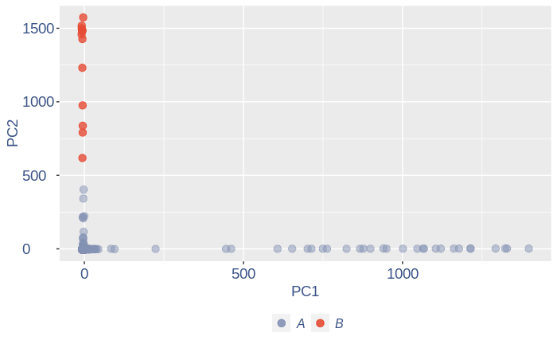

```r
#ttm = clean.sqrt(obj, cells)
obj = ttm$object

ttm$pca.cell.2
```

```
null device
          1
             used    (Mb) gc trigger    (Mb)   max used    (Mb)
Ncells   20209059  1079.3   37716161  2014.3   28897540  1543.3
Vcells 2957114784 22561.0 5014658222 38258.9 4948915980 37757.3
[1] "Start estimation mu with linear method"
[1] 14432  7662
```

|  | rowname | p0-WT2_AAGAAAGACTCN | p0-WT2_AAGAATAGACTC | p0-WT2_ACGCTTAGATCT | p0-WT2_ACGTTCCCCGTC | p0-WT2_ATCCACGGAGCN | p0-WT2_ATTAGGGTCAAG | p0-WT2_GTCATTCCTCTC | p0-WT2_GTCTTATTAGTA | p0-WT2_TTAATAGAATCT | p0-WT3_AAATCTGCTGGA | p0-WT3_AAGTAATAGCAC | p0-WT3_AATAGCCGGATG | p0-WT3_AGTAAATGCCGG | p0-WT3_CTTTTCAATATG | p0-WT3_GACGTTCCCGCA | p0-WT3_GCGTTGTAGCAG | p0-WT3_TCTGGCCGCACT | p0-WT3_TGGGCGTTCCCG | p0-WT3_TTAGGCTTCCCG | p0-WT4_CCCATACTGTAG | p0-WT4_GCGACGGATATT | p0-WT4_TCCAAAGTTGAG | p0-WT4_TCCGGAGGGTCC | p0-WT4_TCGGAACGGTCC | p0-WT4_TGTATAGGAAAG | p0-WT4_TTGTTTTGCACG |
| --- | --- | --- | --- | --- | --- | --- | --- | --- | --- | --- | --- | --- | --- | --- | --- | --- | --- | --- | --- | --- | --- | --- | --- | --- | --- | --- | --- |
| 13254 | Ttr | 1217.302279 | 1123.775923 | 752.020748 | 764.941504 | 952.234482 | 901.949597 | 869.287587 | 1164.869643 | 704.390419 | 1070.650373 | 1107.917463 | 1217.527817 | 1067.929605 | 1331.918004 | 609.055540 | 1326.094995 | 1049.745426 | 943.212474 | 1401.048190 | 1296.302791 | 879.780671 | 1004.460920 | 1180.578131 | 827.202477 | 655.456794 | 716.143243 |
| 7439 | Malat1 | 0.000000 | 2.493586 | 32.621023 | 23.131518 | 29.243285 | 23.358501 | 41.957614 | 15.891810 | 36.911288 | 13.917776 | 21.452791 | 0.000000 | 25.175972 | 1.716389 | 20.954534 | 0.000000 | 34.982260 | 23.031932 | 33.450186 | 1.893795 | 25.312508 | 22.938410 | 20.872100 | 46.918349 | 19.988266 | 17.691844 |
| 62 | 1500015O10Rik | 11.226767 | 14.130319 | 18.337262 | 17.081736 | 14.621643 | 8.097614 | 10.199641 | 7.945905 | 30.759407 | 14.936150 | 10.488031 | 10.274496 | 14.637193 | 1.716389 | 30.916525 | 15.343248 | 11.938390 | 3.290276 | 10.292365 | 10.415873 | 17.559127 | 14.487417 | 13.045062 | 10.929843 | 18.009230 | 12.610144 |
| 1294 | Apoe | 0.000000 | 6.649562 | 21.811690 | 18.861084 | 31.070991 | 22.424161 | 8.345161 | 6.356724 | 9.227822 | 7.468075 | 8.581116 | 2.568624 | 22.248533 | 17.163892 | 21.641567 | 13.151355 | 6.663288 | 18.644898 | 5.146183 | 3.787590 | 17.787168 | 15.694702 | 28.699137 | 12.262750 | 3.760169 | 8.281288 |
| 6477 | Igfbp2 | 16.038238 | 9.974343 | 9.651190 | 16.725867 | 18.277053 | 6.228934 | 13.676791 | 14.302629 | 6.151881 | 7.128617 | 12.394946 | 10.274496 | 5.854877 | 8.581946 | 15.458262 | 26.302711 | 11.660753 | 12.064346 | 14.152002 | 11.362771 | 11.630071 | 10.865563 | 16.088910 | 11.463006 | 13.259543 | 14.304044 |
| 1971 | Bsg | 14.434414 | 9.974343 | 11.002357 | 16.014128 | 14.621643 | 11.523527 | 14.835841 | 11.124267 | 1.537970 | 9.165365 | 11.441488 | 2.568624 | 8.196828 | 15.447503 | 11.679576 | 10.959463 | 12.216027 | 9.870828 | 9.005819 | 7.575181 | 12.314193 | 12.072848 | 16.523745 | 9.330353 | 9.499374 | 13.739410 |
| 1413 | Arl6ip1 | 17.642062 | 14.130319 | 13.511666 | 9.252607 | 10.966232 | 15.260888 | 7.417921 | 9.535086 | 12.303763 | 13.238860 | 11.441488 | 2.568624 | 7.025853 | 6.865557 | 16.488813 | 8.767570 | 7.773835 | 9.870828 | 9.005819 | 9.468976 | 12.770274 | 7.243709 | 7.392202 | 4.265304 | 16.623904 | 15.997944 |
| 847 | Actb | 12.830591 | 20.779880 | 9.844214 | 5.338043 | 7.310821 | 11.212081 | 6.490681 | 7.945905 | 6.151881 | 11.202112 | 8.104388 | 12.843120 | 4.098414 | 10.298335 | 5.839788 | 4.383785 | 6.940925 | 10.967587 | 11.578911 | 6.628283 | 4.104731 | 4.829139 | 2.609012 | 5.864794 | 9.301470 | 3.387800 |
| 4804 | Fth1 | 20.849710 | 18.286295 | 7.913976 | 9.786411 | 3.655411 | 5.917487 | 6.722491 | 11.124267 | 3.075941 | 8.825907 | 3.813829 | 2.568624 | 8.196828 | 5.149168 | 8.931441 | 4.383785 | 6.663288 | 6.580552 | 3.859637 | 4.734488 | 7.297299 | 3.621854 | 6.522531 | 6.931120 | 8.114048 | 7.716655 |
| 3142 | Cst3 | 9.622943 | 7.480757 | 8.493047 | 4.982173 | 12.793937 | 6.851827 | 7.417921 | 7.945905 | 0.000000 | 8.146991 | 9.534574 | 7.705872 | 2.341951 | 6.865557 | 8.587924 | 0.000000 | 8.606746 | 10.967587 | 5.146183 | 5.681385 | 4.788853 | 13.280132 | 8.696708 | 5.864794 | 4.749687 | 7.904866 |

[output cut: 5 more lines]

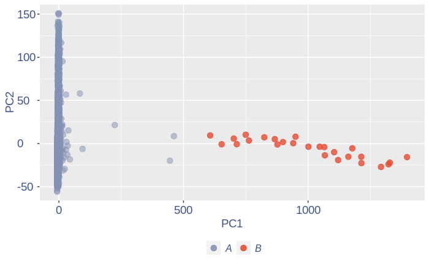

```
null device
          1
             used    (Mb) gc trigger    (Mb)   max used    (Mb)
Ncells   20209294  1079.3   37716161  2014.3   28897540  1543.3
Vcells 2956319656 22555.0 5014658222 38258.9 4962962997 37864.5
[1] "Start estimation mu with linear method"
[1] 14387  7636
```

|  | rowname | p0-WT4_CGTAAACCCAGC |
| --- | --- | --- |
| 7649 | Meg3 | 282.81485 |
| 7410 | Malat1 | 210.09103 |
| 11714 | Snhg11 | 56.56297 |
| 11815 | Son | 16.16085 |
| 1938 | Brd8 | 12.12064 |
| 2560 | Celf4 | 12.12064 |
| 2804 | Clta | 12.12064 |
| 4711 | Fnbp1l | 12.12064 |
| 6330 | Hsp90b1 | 12.12064 |
| 6891 | Kif5c | 12.12064 |

[output cut: 5 more lines]

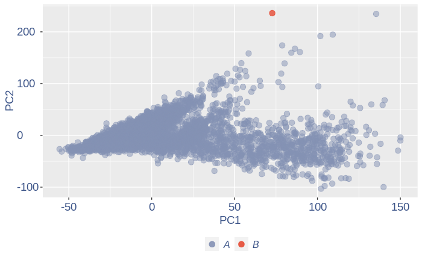

Run this only in the last iteration, instead the previus code, when B cells group has not to be removed

```r
pdf(paste(out_dir,"cleaning/",t,"_",n_it,"_plots_before_cells_exlusion.pdf", sep = ""))
ttm$pca.cell.2
ggplot(ttm$D, aes(x=n,y=means)) + geom_point() +
  geom_text_repel(data=subset(ttm$D, n > (max(ttm$D$n)- 15) ), aes(n,means,label=rownames(ttm$D[ttm$D$n > (max(ttm$D$n)- 15),])),
                  nudge_y      = 0.05,
                  nudge_x      = 0.05,
                  direction    = "x",
                  angle        = 90,
                  vjust        = 0,
                  segment.size = 0.2)+
  ggtitle(label = "B cell group genes mean expression", subtitle = " - B group NOT removed -")+my_theme +
  theme(plot.title = element_text(color = "#3C5488FF", size = 20, face = "italic",vjust = - 10,hjust = 0.02 ),
        plot.subtitle = element_text(color = "darkred",vjust = - 15,hjust = 0.01 ))
```

```r
dev.off()
```

To color the pca based on nu_j (so the cells’ efficiency)

```r
nu_est = round(obj@nu, digits = 7)

plot.nu <-ggplot(ttm$pca_cells,aes(x=PC1,y=PC2, colour = log(nu_est)))

plot.nu = plot.nu + geom_point(size = 1,alpha= 0.8)+
  scale_color_gradient2(low = "#E64B35B2",mid =  "#4DBBD5B2", high =  "#3C5488B2" ,
                        midpoint = log(mean(nu_est)),name = "ln (nu)")+
  ggtitle("Cells PCA coloured by cells efficiency") +
  my_theme +  theme(plot.title = element_text(color = "#3C5488FF", size = 20),
                    legend.title=element_text(color = "#3C5488FF", size = 14,face = "italic"),
                    legend.text = element_text(color = "#3C5488FF", size = 11),
                    legend.key.width = unit(2, "mm"),
                    legend.position="right")

pdf(paste(out_dir,"cleaning/",t,"_plots_PCA_efficiency_colored.pdf", sep = ""))
plot.nu
dev.off()
```

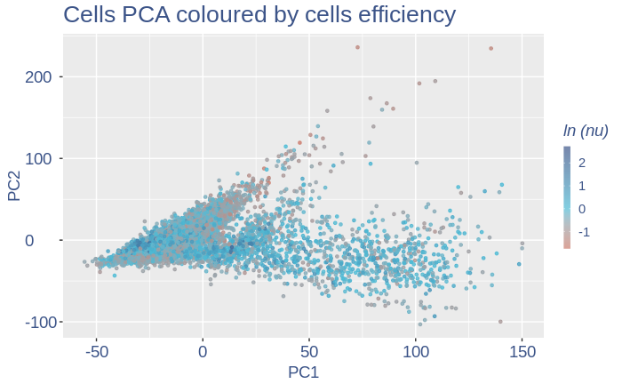

```r
plot.nu
```

The next part is use to remove the cells with efficiency too low.

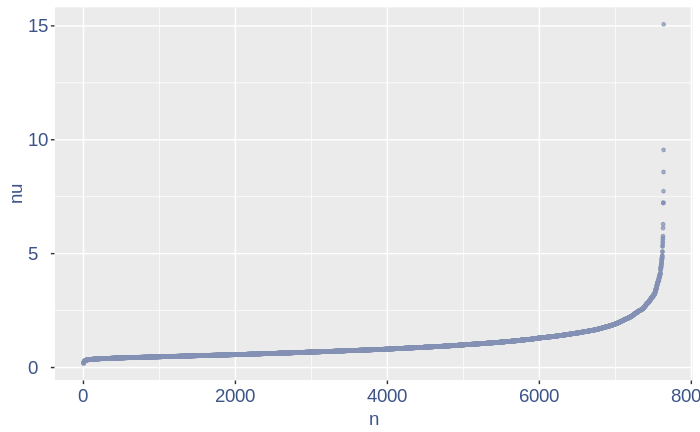

```r
nu_df = data.frame("nu"= sort(obj@nu), "n"=c(1:length(obj@nu)))

ggplot(nu_df, aes(x = n, y=nu)) +
    geom_point(colour = "#8491B4B2", size=1)+
    my_theme #+ ylim(0,1) + xlim(0,70)
```

We can zoom on the smalest values and, if we detect a clear elbow, we can decide to remove the cells.

```r
yset = 0.35#threshold to remove low UDE cells
plot.ude <- ggplot(nu_df, aes(x = n, y=nu)) +
    geom_point(colour = "#8491B4B2", size=1) +
    my_theme + ylim(0.,0.7) + xlim(0,2000) +
    geom_hline(yintercept=yset, linetype="dashed", color = "darkred") +
    annotate(geom="text", x=500, y=0.5,
             label=paste("to remove cells with nu < ",yset,sep = " "),
             color="darkred", size=4.5)


pdf(paste(out_dir,"cleaning/",t,"_plots_efficiency.pdf", sep = ""))
plot.ude
dev.off()
```

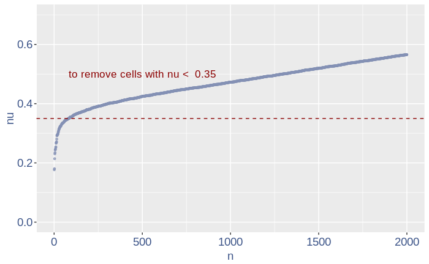

```r
plot.ude
```

We also save the defined treshold in the metadata and re run the estimation

```r
obj@meta[(nrow(obj@meta)+1),1:2] = c("Threshold low UDE cells:",yset)

to_rem = rownames(nu_df[which(nu_df$nu < yset),])

obj@raw = obj@raw[, !colnames(obj@raw) %in% to_rem]
```

Repeat the estimation after the cells are removed

```r
ttm = clean(obj)
```

```
[1] "Start estimation mu with linear method"
[1] 14382  7554
```

|  | rowname | p0-WT2_AAAGTGCTAGCC | p0-WT2_GAAGTTAGGGAN | p0-WT2_GATCTAGCGTGG | p0-WT2_GATCTAGCGTGN | p0-WT2_GGATCCGCCCAA | p0-WT3_AACAGTGCAGAA | p0-WT3_GCCTTCCTCCGA |
| --- | --- | --- | --- | --- | --- | --- | --- | --- |
| 1287 | Apoe | 277.40779 | 270.637698 | 273.898393 | 229.480218 | 285.411229 | 270.247259 | 227.176931 |
| 12839 | Tmsb4x | 42.12655 | 42.389037 | 62.922604 | 67.598824 | 97.457493 | 32.923524 | 57.665013 |
| 3169 | Ctsd | 95.45696 | 44.019385 | 7.402659 | 5.336749 | 29.585310 | 12.346321 | 72.758540 |
| 3167 | Ctsb | 52.43411 | 45.649732 | 11.103989 | 7.115666 | 27.844998 | 9.602694 | 56.890986 |
| 841 | Actb | 25.54482 | 39.128342 | 43.182179 | 23.125913 | 43.507809 | 16.461762 | 16.254567 |
| 3127 | Cst3 | 30.02637 | 37.497994 | 12.337765 | 12.452415 | 31.325623 | 27.436270 | 37.540311 |
| 2009 | C1qb | 17.02988 | 35.867647 | 25.909307 | 37.357245 | 24.364373 | 20.577202 | 18.189635 |
| 2011 | C1qc | 22.85589 | 30.976604 | 25.909307 | 17.789164 | 19.143436 | 17.833575 | 26.703932 |
| 4784 | Fth1 | 28.23375 | 9.782085 | 9.870212 | 17.789164 | 22.624061 | 17.833575 | 22.059770 |
| 1667 | B2m | 18.37434 | 32.606952 | 18.506648 | 16.010248 | 17.403124 | 10.974508 | 13.545473 |

[output cut: 5 more lines]

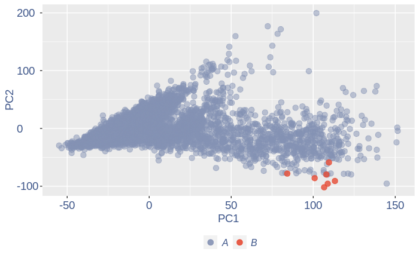

```r
obj = ttm$object
ttm$pca.cell.2
```

Just to check again, we plot the final efficiency colored PCA

```r
nu_est = round(obj@nu, digits = 7)
plot.nu <-ggplot(ttm$pca_cells,aes(x=PC1,y=PC2, colour = log(nu_est)))
plot.nu = plot.nu + geom_point(size = 2,alpha= 0.8)+
  scale_color_gradient2(low = "#E64B35B2",mid =  "#4DBBD5B2", high =  "#3C5488B2" ,
                        midpoint = log(mean(nu_est)),name = "ln(nu)")+
  ggtitle("Cells PCA coloured by cells efficiency: last") +
  my_theme +  theme(plot.title = element_text(color = "#3C5488FF", size = 20),
                    legend.title=element_text(color = "#3C5488FF", size = 14,face = "italic"),
                    legend.text = element_text(color = "#3C5488FF", size = 11),
                    legend.key.width = unit(2, "mm"),
                    legend.position="right")

pdf(paste(out_dir,"cleaning/",t,"_plots_PCA_efficiency_colored_FINAL.pdf", sep = ""))
plot.nu
dev.off()
```

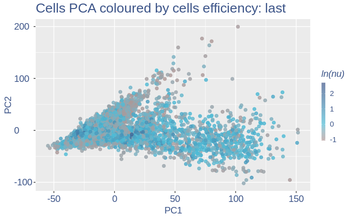

```r
plot.nu
```

COTAN analysis: in this part all the contingency tables are computed and used to get the statistics (S) To storage efficincy of all the observed tables only the yes_yes is stored. Note that if will be necessary re-coputing the yes-yes table, the yes-yes table should be cancelled before running cotan_analysis.

```r
# obj@yes_yes = c()
obj = cotan_analysis(obj)
```

COEX evaluation and storing

```r
saveRDS(obj,file = paste(out_dir,t,".cotan.RDS", sep = ""))

obj = get.coex(obj)

# saving the structure
saveRDS(obj,file = paste(out_dir,t,".cotan.RDS", sep = ""))
```

## 0.3 Analysis of the elaborated data

### 0.3.1 GDI

The next function can directly plot the GDI for the dataset with the 1.5 threshold (in red) and the two higher quantiles (in blue).

```
[1] "GDI plot "
[1] "function to generate GDI dataframe"
[1] "Using S"
[1] "function to generate S "
```

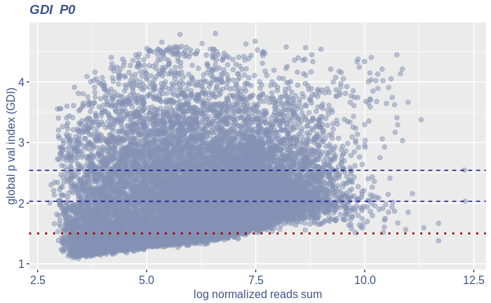

```r
obj = readRDS(paste(out_dir,t,".cotan.RDS", sep = ""))
plot.GDI(obj, cond = "P0")
```

If a more complex plot is needed, or if we want to analize mor in detail the GDI data, we can get direcly the GDI dataframe.

```r
quant.p = get.GDI(obj)
```

```
[1] "function to generate GDI dataframe"
[1] "Using S"
[1] "function to generate S "
```

```r
head(quant.p)
```

|  | sum.raw.norm | GDI | exp.cells |
| --- | --- | --- | --- |
| 0610005C13Rik | 3.439025 | 1.261301 | 0.3177125 |
| 0610007N19Rik | 5.352070 | 2.599832 | 2.0916071 |
| 0610007P14Rik | 7.718572 | 2.070818 | 23.1135822 |
| 0610009B22Rik | 7.075439 | 2.047966 | 13.5954461 |
| 0610009D07Rik | 8.811660 | 1.861726 | 51.6944665 |
| 0610009E02Rik | 4.905004 | 2.297613 | 1.7209425 |

In the third column of this dataframe is reported the percentage of cells expressing the gene.

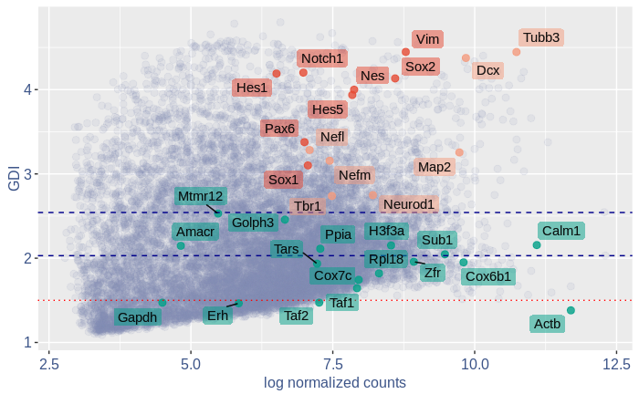

```r
NPGs=c("Nes","Vim","Sox2","Sox1","Notch1", "Hes1","Hes5","Pax6") #,"Hes3"
PNGs=c("Map2","Tubb3","Neurod1","Nefm","Nefl","Dcx","Tbr1")
hk=c("Calm1","Cox6b1","Ppia","Rpl18","Cox7c","Erh","H3f3a","Taf1","Taf2","Gapdh","Actb","Golph3", "Mtmr12", "Zfr", "Sub1", "Tars", "Amacr")

text.size = 12

quant.p$highlight = with(quant.p, ifelse(rownames(quant.p) %in% NPGs, "NPGs",
                                                 ifelse(rownames(quant.p) %in% hk,"Constitutive" ,
                                                               ifelse(rownames(quant.p) %in% PNGs,"PNGs" , "normal"))))

textdf <- quant.p[rownames(quant.p) %in% c(NPGs,hk,PNGs), ]
mycolours <- c("Constitutive" = "#00A087FF","NPGs"="#E64B35FF","PNGs"="#F39B7FFF","normal" = "#8491B4B2")
f1 = ggplot(subset(quant.p,highlight == "normal" ), aes(x=sum.raw.norm, y=GDI)) +  geom_point(alpha = 0.1, color = "#8491B4B2", size=2.5)
GDI_plot = f1 +  geom_point(data = subset(quant.p,highlight != "normal"  ), aes(x=sum.raw.norm, y=GDI, colour=highlight),size=2.5,alpha = 0.8) +
  geom_hline(yintercept=quantile(quant.p$GDI)[4], linetype="dashed", color = "darkblue") +
  geom_hline(yintercept=quantile(quant.p$GDI)[3], linetype="dashed", color = "darkblue") +
  geom_hline(yintercept=1.5, linetype="dotted", color = "red", size= 0.5) +
  scale_color_manual("Status", values = mycolours)  +
  scale_fill_manual("Status", values = mycolours)  +
  xlab("log normalized counts")+ylab("GDI")+
  geom_label_repel(data =textdf , aes(x=sum.raw.norm, y=GDI, label = rownames(textdf),fill=highlight),
                   label.size = NA,
                   alpha = 0.5,
                   direction ="both",
                   na.rm=TRUE,
                   seed = 1234) +
  geom_label_repel(data =textdf , aes(x=sum.raw.norm, y=GDI, label = rownames(textdf)),
                   label.size = NA,
                   segment.color = 'black',
                   segment.size = 0.5,
                   direction = "both",
                   alpha = 0.8,
                   na.rm=TRUE,
                   fill = NA,
                   seed = 1234) +
  theme(axis.text.x = element_text(size = text.size, angle = 0, hjust = .5, vjust = .5, face = "plain", colour ="#3C5488FF" ),
        axis.text.y = element_text( size = text.size, angle = 0, hjust = 0, vjust = .5, face = "plain", colour ="#3C5488FF"),
        axis.title.x = element_text( size = text.size, angle = 0, hjust = .5, vjust = 0, face = "plain", colour ="#3C5488FF"),
        axis.title.y = element_text( size = text.size, angle = 90, hjust = .5, vjust = .5, face = "plain", colour ="#3C5488FF"),
        legend.title = element_blank(),
        legend.text = element_text(color = "#3C5488FF",face ="italic" ),
        legend.position = "bottom")  # titl)
legend <- cowplot::get_legend(GDI_plot)
GDI_plot =GDI_plot + theme(
        legend.position = "none")
GDI_plot
```

### 0.3.2 Heatmaps

```
[1] "plot heatmap"
[1] "Loading condition P0_cortex"
[1] "Map2"    "Tubb3"   "Neurod1" "Nefm"    "Nefl"    "Dcx"     "Tbr1"
[1] "Get p-values on a set of genes on columns on a set of genes on rows"
[1] "Using function S"
[1] "function to generate S "
[1] "Ref.col"
[1] "NPGs"
[1] "Const."
[1] "min coex: -0.00402368455132171 max coex 0.00363639659040585"
```

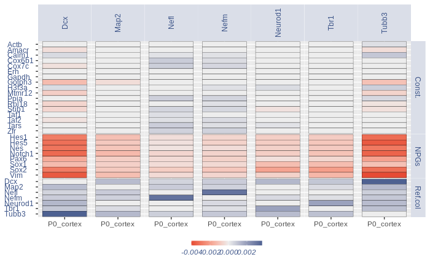

```r
list.genes = list("Ref.col"= PNGs, "NPGs"=NPGs, "Const."=hk )

plot.heatmap(df_genes = list.genes,sets = c(1:3),conditions = "P0_cortex",dir = "Data/")
```